# Predicting the weight of new born babies

Cynara Nyahoda, Tendai Makuwerere

2/14/2022

### Introduction

In this project, we will predict the weight of new born babies using three different regression models and ultimately selecting the best performing model amongst the three. The variables that are used to predict the new born weights are primarily attributes about the mother.

The data set we are using has 101400 rows (samples) and 37 columns (variables) where each sample signifies a unique case of a new born baby.The last column in the data set, the BWEIGHT, is what our models will be trained to predict.

### Data Preparation

#### Install and loading necessary packages

```r
requiredPackages = c("dplyr","caret" , "glmnet", "ggplot2", "tidypredict","tidyverse", "corrplot", "olsrr", "pROC", "gbm", "tree")

for(i in requiredPackages){if(!require(i,character.only = TRUE)) install.packages(i)}
for(i in requiredPackages){if(!require(i,character.only = TRUE)) library(i,character.only = TRUE)}
```

The data set was taken from kaggle and is available [here](https://www.kaggle.com/c/birth-weight-prediction/data?select=baby-weights-dataset.csv)

```r
setwd('C:\\Users\\Mark Asamoah\\OneDrive\\Desktop\\Cynara\\ML2\\birth-weight-prediction')
baby_weight <- read.csv("baby-weights.csv", header = TRUE)
head(baby_weight,10) # the top 10 rows
```

```
##      ID SEX MARITAL FAGE GAINED VISITS MAGE FEDUC MEDUC TOTALP BDEAD TERMS
## 1  2001   2       1   33     26     10   34    12     4      2     0     0
## 2  2002   2       2   19     40     10   18    11    12      1     0     0
## 3  2003   2       1   33     16     14   31    16    16      2     0     0
## 4  2004   1       1   25     40     15   28    12    12      3     0     0
## 5  2005   1       2   21     60     13   20    12    14      2     0     0
## 6  2006   1       1   21     30     15   21    12    13      1     0     0
## 7  2007   1       2   29     20     11   32     6     6      2     0     0
## 8  2008   2       2   23     41     15   21    13    13      1     0     0
## 9  2009   2       1   27      0     12   26    10    13      1     0     0
## 10 2010   1       1   30     30     10   22    12    14      3     0     0
##    LOUTCOME WEEKS RACEMOM RACEDAD HISPMOM HISPDAD CIGNUM DRINKNUM ANEMIA
## 1         1    35       1       1       M       M      0        0      0
## 2         9    41       1       1       N       N      0        0      0
## 3         1    39       1       1       N       N      0        0      0
```

[output cut: 29 more lines]

```r
tail(baby_weight,10) #the bottom 10 rows
```

```
##            ID SEX MARITAL FAGE GAINED VISITS MAGE FEDUC MEDUC TOTALP BDEAD
## 101391 103391   2       1   33     60     12   32    16    12      5     0
## 101392 103392   1       1   21     35     15   20    12    11      1     0
## 101393 103393   1       1   29     34     11   24    16    14      1     0
## 101394 103394   2       1   33      9     19   30    16    16      1     0
## 101395 103395   2       1   35     20     15   30     6     8      3     0
## 101396 103396   1       2   36      0      9   34     3    12      4     0
## 101397 103397   2       2   21     39     11   19    12     9      2     0
## 101398 103398   2       1   27     37     15   22    12    12      2     0
## 101399 103399   1       1   27     26     12   24    12    14      1     0
## 101400 103400   1       2   20     31     15   17    12    11      1     0
##        TERMS LOUTCOME WEEKS RACEMOM RACEDAD HISPMOM HISPDAD CIGNUM DRINKNUM
## 101391     2        1    39       1       1       N       N      0        0
## 101392     0        9    38       1       1       S       P      0        0
## 101393     0        9    39       1       1       S       N      0        0
```

[output cut: 29 more lines]

```r
str(baby_weight)
```

```
## 'data.frame':    101400 obs. of  37 variables:
##  $ ID      : int  2001 2002 2003 2004 2005 2006 2007 2008 2009 2010 ...
##  $ SEX     : int  2 2 2 1 1 1 1 2 2 1 ...
##  $ MARITAL : int  1 2 1 1 2 1 2 2 1 1 ...
##  $ FAGE    : int  33 19 33 25 21 21 29 23 27 30 ...
##  $ GAINED  : int  26 40 16 40 60 30 20 41 0 30 ...
##  $ VISITS  : int  10 10 14 15 13 15 11 15 12 10 ...
##  $ MAGE    : int  34 18 31 28 20 21 32 21 26 22 ...
##  $ FEDUC   : int  12 11 16 12 12 12 6 13 10 12 ...
##  $ MEDUC   : int  4 12 16 12 14 13 6 13 13 14 ...
##  $ TOTALP  : int  2 1 2 3 2 1 2 1 1 3 ...
##  $ BDEAD   : int  0 0 0 0 0 0 0 0 0 0 ...
##  $ TERMS   : int  0 0 0 0 0 0 0 0 0 0 ...
##  $ LOUTCOME: int  1 9 1 1 1 9 1 9 9 1 ...
##  $ WEEKS   : int  35 41 39 38 40 42 39 41 38 39 ...
```

[output cut: 23 more lines]

Below we will perform exploratory data analysis to get a general statistical view of the dataset.

#### Missing data(NA)

```r
sum(is.na(baby_weight))
```

```
## [1] 5
```

Our data has 5 NA’s, therefore we will remove them since their impact on the data is insignificant.

```r
baby_weight <- na.omit(baby_weight)
sum(is.na(baby_weight))
```

```
## [1] 0
```

#### Outliers

Checking for extreme outliers is important because they can affect the accuracy of our model. A statistical analysis will be appropriate for this check.

```r
summary(baby_weight)
```

```
##        ID              SEX           MARITAL           FAGE
##  Min.   :  2001   Min.   :1.000   Min.   :1.000   Min.   :14.00
##  1st Qu.: 27355   1st Qu.:1.000   1st Qu.:1.000   1st Qu.:25.00
##  Median : 52703   Median :1.000   Median :1.000   Median :30.00
##  Mean   : 52703   Mean   :1.486   Mean   :1.304   Mean   :30.17
##  3rd Qu.: 78052   3rd Qu.:2.000   3rd Qu.:2.000   3rd Qu.:35.00
##  Max.   :103400   Max.   :9.000   Max.   :2.000   Max.   :74.00
##      GAINED          VISITS           MAGE           FEDUC
##  Min.   : 0.00   Min.   : 0.00   Min.   :11.00   Min.   : 0.00
##  1st Qu.:21.00   1st Qu.:10.00   1st Qu.:23.00   1st Qu.:12.00
##  Median :30.00   Median :12.00   Median :28.00   Median :12.00
##  Mean   :30.28   Mean   :12.44   Mean   :27.74   Mean   :12.93
##  3rd Qu.:39.00   3rd Qu.:15.00   3rd Qu.:32.00   3rd Qu.:16.00
##  Max.   :98.00   Max.   :49.00   Max.   :53.00   Max.   :17.00
##      MEDUC           TOTALP           BDEAD           TERMS
##  Min.   : 0.00   Min.   : 1.000   Min.   :0.000   Min.   : 0.0000
##  1st Qu.:12.00   1st Qu.: 1.000   1st Qu.:0.000   1st Qu.: 0.0000
##  Median :13.00   Median : 2.000   Median :0.000   Median : 0.0000
##  Mean   :13.26   Mean   : 2.378   Mean   :0.015   Mean   : 0.3716
##  3rd Qu.:16.00   3rd Qu.: 3.000   3rd Qu.:0.000   3rd Qu.: 0.0000
##  Max.   :17.00   Max.   :20.000   Max.   :6.000   Max.   :16.0000
##     LOUTCOME         WEEKS          RACEMOM         RACEDAD
##  Min.   :1.000   Min.   :18.00   Min.   :0.000   Min.   :0.00
##  1st Qu.:1.000   1st Qu.:38.00   1st Qu.:1.000   1st Qu.:1.00
##  Median :1.000   Median :39.00   Median :1.000   Median :1.00
##  Mean   :3.859   Mean   :38.74   Mean   :1.441   Mean   :1.44
##  3rd Qu.:9.000   3rd Qu.:40.00   3rd Qu.:1.000   3rd Qu.:1.00
##  Max.   :9.000   Max.   :45.00   Max.   :8.000   Max.   :9.00
##    HISPMOM            HISPDAD              CIGNUM           DRINKNUM
##  Length:101395      Length:101395      Min.   : 0.0000   Min.   : 0.00000
##  Class :character   Class :character   1st Qu.: 0.0000   1st Qu.: 0.00000
##  Mode  :character   Mode  :character   Median : 0.0000   Median : 0.00000
##                                        Mean   : 0.7261   Mean   : 0.00555
##                                        3rd Qu.: 0.0000   3rd Qu.: 0.00000
##                                        Max.   :60.0000   Max.   :40.00000
##      ANEMIA          CARDIAC             ACLUNG           DIABETES
##  Min.   :0.0000   Min.   :0.000000   Min.   :0.00000   Min.   :0.00000
##  1st Qu.:0.0000   1st Qu.:0.000000   1st Qu.:0.00000   1st Qu.:0.00000
##  Median :0.0000   Median :0.000000   Median :0.00000   Median :0.00000
##  Mean   :0.0356   Mean   :0.004251   Mean   :0.01125   Mean   :0.03307
```

[output cut: 15 more lines]

```
##  Max.   :1.00000   Max.   :1.000000   Max.   :1.000000   Max.   :1.000000
##     PRETERM             RENAL             RHSEN             UTERINE
##  Min.   :0.000000   Min.   :0.00000   Min.   :0.000000   Min.   :0.000000
##  1st Qu.:0.000000   1st Qu.:0.00000   1st Qu.:0.000000   1st Qu.:0.000000
##  Median :0.000000   Median :0.00000   Median :0.000000   Median :0.000000
##  Mean   :0.008856   Mean   :0.00219   Mean   :0.003777   Mean   :0.003442
##  3rd Qu.:0.000000   3rd Qu.:0.00000   3rd Qu.:0.000000   3rd Qu.:0.000000
##  Max.   :1.000000   Max.   :1.00000   Max.   :1.000000   Max.   :1.000000
##     BWEIGHT
##  Min.   : 0.1875
##  1st Qu.: 6.6250
##  Median : 7.3750
##  Mean   : 7.2581
##  3rd Qu.: 8.0625
##  Max.   :13.0625
```

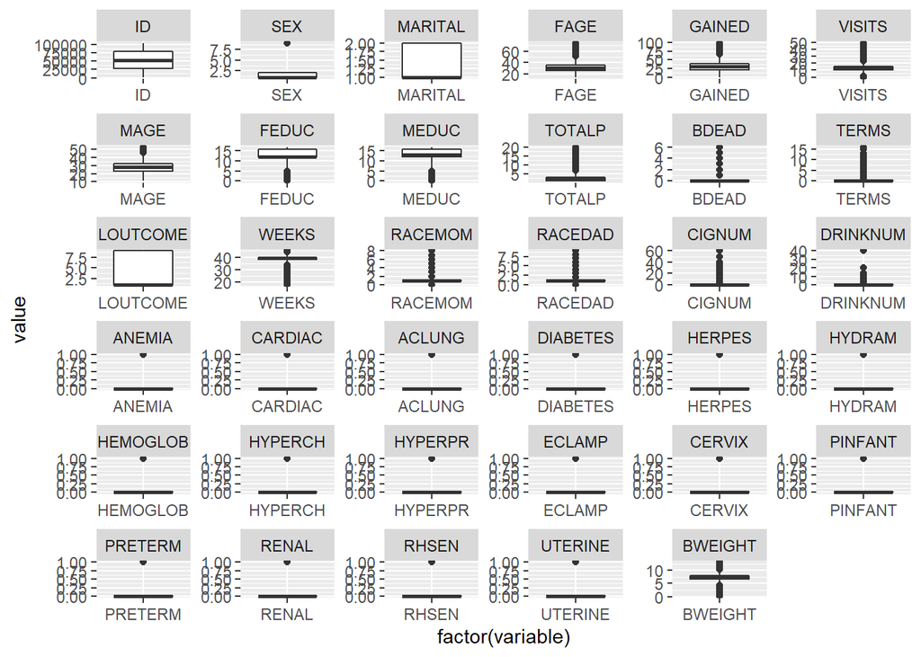

```r
library(reshape)
meltData <- melt(baby_weight)
p <- ggplot(meltData, aes(factor(variable), value))
p + geom_boxplot() + facet_wrap(~variable, scale="free")
```

Although some variables contain outliers, we will not remove them as they neither affect the results nor the assumptions.

### Distribution of the dependent variable

From plotting the distribution of the dependent variable BWEIGHT, we can see that the distribution is left skewed. Meaning that quite a number of baby weights are within the lower quartile of the distribution.

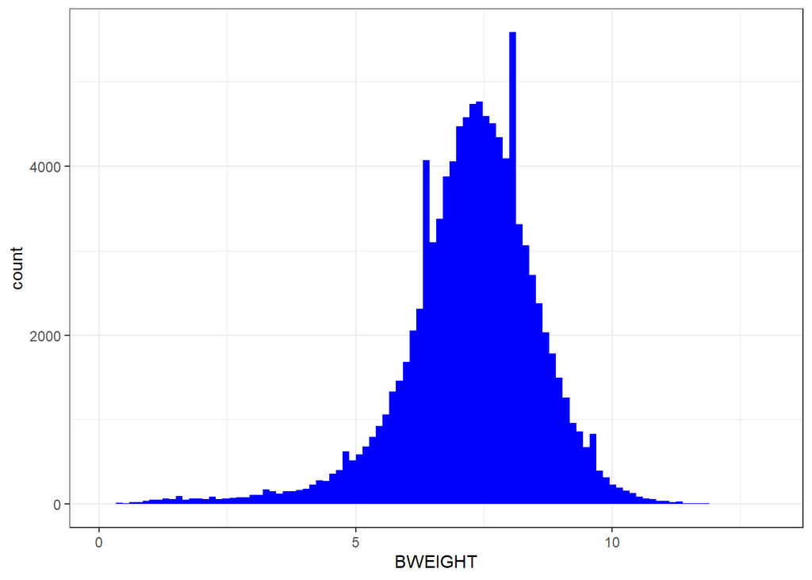

```r
ggplot(baby_weight,
       aes(x = BWEIGHT)) +
  geom_histogram(fill = "blue",
                 bins = 100) +
  theme_bw()
```

### Removing single level variables

```r
vars_selected <-names(baby_weight)
var_to_remove <- nearZeroVar(baby_weight,
                                      names = TRUE)

var_to_remove
```

```
##  [1] "BDEAD"    "CIGNUM"   "DRINKNUM" "ANEMIA"   "CARDIAC"  "ACLUNG"
##  [7] "DIABETES" "HERPES"   "HYDRAM"   "HEMOGLOB" "HYPERCH"  "ECLAMP"
## [13] "CERVIX"   "PINFANT"  "PRETERM"  "RENAL"    "RHSEN"    "UTERINE"
```

```r
vars_selected <- names(baby_weight)[
  !names(baby_weight) %in% var_to_remove
]

baby_weight <- baby_weight[,vars_selected]
```

### Removing strongly correlated independent variables

Strongly correlated variables by virtue that they move in the same direction, do not have much of a significance in improving the results of a model, hence why they are normally removed.Before we can check and remove any strongly correlated variables, we will make non-numeric variables NULL.

```r
# Remove the columns that are not numeric

baby_weight$HISPMOM <- NULL
baby_weight$HISPDAD <- NULL
baby_weight$ID <- NULL

baby_weight_correlations <- cor(baby_weight,
    use = "pairwise.complete.obs")

baby_weight_cor_order <-
  baby_weight_correlations[,"BWEIGHT"] %>%
  sort(decreasing = TRUE) %>% # sort the correlations with BWEIGHT in decreasing order
  names()
```

#### Plotting correlations

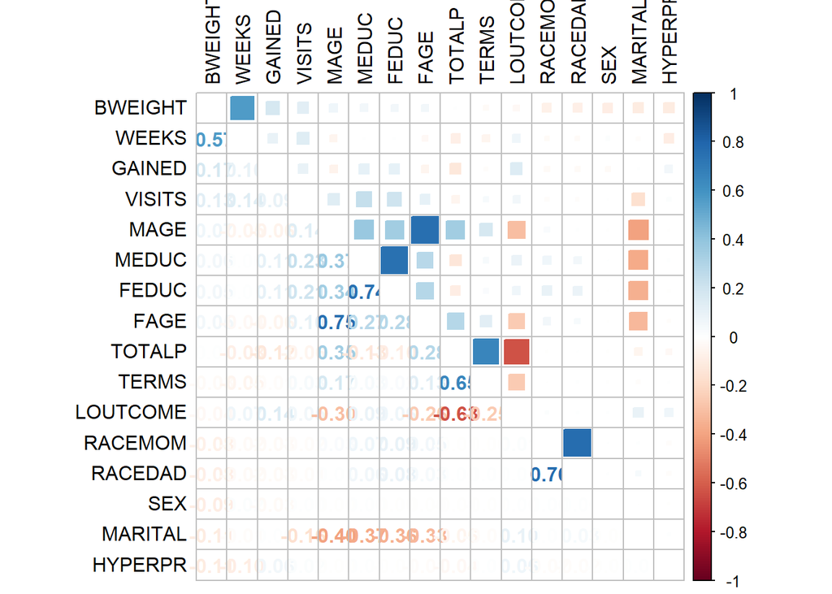

```r
corrplot.mixed(baby_weight_correlations[baby_weight_cor_order,
                                   baby_weight_cor_order],
               upper = "square",
               lower = "number",
               tl.col = "black",
               tl.pos = "lt")
```

The variables that have the darkest shade of blue squares are strongly correlated.We ought to remove some of them.

```r
vars_to_remove <- findCorrelation(baby_weight_correlations[-8,-8],
                cutoff = 0.7, # threshold
                names = TRUE)

vars_selected <- names(baby_weight)[
  !names(baby_weight) %in% vars_to_remove
]
```

Two variables have been removed,that is ‘MAGE’ and ‘RACEDAD’.

```r
baby_weight <- baby_weight[,vars_selected]
```

### Removing Insignificant variables

Insignificant variables will not improve our models in any way hence they can be removed using automated backward elimination to improve the efficiency of the task.

1. Running the linear model with all variables

```r
modelWithallVars <- lm(BWEIGHT ~ .,
                          data = baby_weight %>%
                            dplyr::select(all_of(vars_selected)))
```

```r
Model_varsRemoved <- ols_step_backward_p(modelWithallVars,
                    prem = 0.05, # p-value threshold
                    progress = FALSE) # hide progress
```

3. Removing recommended variables

```r
vars_to_remove <- Model_varsRemoved$removed
vars_selected <- vars_selected[!vars_selected %in% vars_to_remove]
```

The variable “FEDUC” was insignificant, therefore it has been removed. All the variables left are significant.

### Training & testing Regression Models

In this project we will be comparing 3 different regression models, including Linear regression, gradient boosting and tree regression model. The baby_weight data set will split into two. 70% of the data set will be used for training and 30% will be used as the test data.

```r
seed <- 123489065
set.seed(seed)
datapart <- createDataPartition(baby_weight$BWEIGHT,
                                    p = 0.70,
                                    list = FALSE)
baby_weight.train <- baby_weight[datapart,]
baby_weight.test  <- baby_weight[-datapart,]
```

```r
Baby_weight.lm <- lm(BWEIGHT ~ .,
                data = baby_weight.train)

Baby_weight.lm.pred <- predict(Baby_weight.lm,
                          newdata = baby_weight.test)
mean((Baby_weight.lm.pred   - baby_weight.test$BWEIGHT) ^ 2)
```

```
## [1] 1.120264
```

#### Gradient Boosting

```r
set.seed(seed)
baby_weight.gbm <- gbm(BWEIGHT ~ .,
                  data = baby_weight.train,
                  distribution = "gaussian",
                  n.trees = 500,
                  interaction.depth = 4)

baby_weight.gbm.pred <- predict(baby_weight.gbm,
                           newdata = baby_weight.test,
                           n.trees = 500)
mean((baby_weight.gbm.pred - baby_weight.test$BWEIGHT) ^ 2)
```

```
## [1] 1.000155
```

#### Tree regression model

```r
baby_weight.tree <- tree(BWEIGHT ~ . ,
                    data = baby_weight.train)
baby_weight.tree.pred <- predict(baby_weight.tree,
                            newdata = baby_weight.test)
mean((baby_weight.tree.pred   - baby_weight.test$BWEIGHT) ^ 2)
```

```
## [1] 1.144991
```

### Summary

We will summarize the statistics of the models applied to our data so we can compare and analyze the performance of each model based on the statistical results.

```r
# summarizes popular error measures
getRegressionMetrics <- function(real, predicted) {


  # Mean Square Error
  MSE <- mean((real - predicted)^2)

  # Root Mean Square Error
  RMSE <- sqrt(MSE)

  # Mean Absolute Error
  MAE <- mean(abs(real - predicted))

  # Median Absolute Error
  MedAE <- median(abs(real - predicted))

  # Mean Logarithmic Absolute Error
  MSLE <- mean((log(1 + real) - log(1 + predicted))^2)

  # Total Sum of Squares
  TSS <- sum((real - mean(real))^2)

  # Explained Sum of Squares
  RSS <- sum((predicted - real)^2)

  # R2
  R2 <- 1 - RSS/TSS

  result <- data.frame(MSE, RMSE, MAE, MedAE, MSLE, R2)
  return(result)
}
```

#### Summary on training data

```r
bind_cols(tibble(baby_weight.tree    =  predict(baby_weight.tree, baby_weight.train),
                 baby_weight.gbm =  predict(baby_weight.gbm, baby_weight.train),
                 Baby_weight.lm = predict(Baby_weight.lm, baby_weight.train),

  )) %>%
  map_dfr(getRegressionMetrics, real = baby_weight.train$BWEIGHT, .id = "Model")
```

```
##              Model      MSE      RMSE       MAE     MedAE       MSLE        R2
## 1 baby_weight.tree 1.130805 1.0633933 0.8309208 0.6772528 0.01996570 0.3557390
## 2  baby_weight.gbm 0.965376 0.9825355 0.7647245 0.6239553 0.01586721 0.4499902
## 3   Baby_weight.lm 1.108864 1.0530259 0.8214121 0.6717880 0.01944397 0.3682400
```

```r
bind_cols(tibble(baby_weight.tree    =  predict(baby_weight.tree, baby_weight.test),
                 baby_weight.gbm =  predict(baby_weight.gbm, baby_weight.test),
                 Baby_weight.lm = predict(Baby_weight.lm, baby_weight.test),

  )) %>%
  map_dfr(getRegressionMetrics, real = baby_weight.test$BWEIGHT, .id = "Model")
```

```
##              Model      MSE     RMSE       MAE     MedAE       MSLE        R2
## 1 baby_weight.tree 1.144991 1.070042 0.8328547 0.6643791 0.02051015 0.3624944
## 2  baby_weight.gbm 1.000155 1.000078 0.7744807 0.6262383 0.01686854 0.4431357
## 3   Baby_weight.lm 1.120264 1.058425 0.8236323 0.6722194 0.02001138 0.3762616
```

### Conclusion

Looking at the R2 results from all 3 models we can see that none of the models are performing well since none of them have an R2 that is above 0.5. This may be due to missing information in the data that possibly affects baby weights more than the available variables used. However, on both the train and test data sets, the Gradient boosting model outperformed the other 2 models.

Based on the Mean Square Error (MSE), the Gradient boosting model has the lowest MSE in both the train and test data, therefore, it still is the better performing model.

In conclusion, all the models under-performed, however, the gradient boosting model perfomed better that the others, thus it is the recommended model for this data set.